# DSAC Modeling Workshop

Eli Gnesin

December 1, 2022

# What is Statistical Learning?

Statistical Learning is this overarching idea that we take a question, we collect data on that question, we used that data to train and validate an algorithm, and then we assess the output of that algorithm and determine if we have/can answer our question.

Predictive modeling, as a subset of this, is the idea of using these algorithms to make a prediction about future data.

## Setup

Here, we load in the necessary code libraries that we will use later. The last lines help set the standards for how the file will render when we turn it into a PDF/HTML.

We also need to load in the dataset. This is a dataset I collected with a friend for a senior project at William & Mary in Fall 2021. The dataset contains statistics and salary information for 805 NHL players in the 2018-2019 season (chosen because it was the last pre-Covid season at the time of data collection). We read this data in as a tibble (a dataframe, but in tidyverse).

```r
data_full = read_csv("NHL_Data.csv")
head(data_full)
```

```
## # A tibble: 6 × 34
##      Rk Player   Age Tm    Pos      GP     G     A   PTS `+/-`   PIM    PS   EVG
##   <dbl> <chr>  <dbl> <chr> <chr> <dbl> <dbl> <dbl> <dbl> <dbl> <dbl> <dbl> <dbl>
## 1   554 Conno…    22 EDM   C        78    41    75   116     3    20  13      31
## 2   826 John …    28 TOR   C        82    47    41    88    19    34  11.3    37
## 3   420 Patri…    30 CHI   RW       81    44    66   110     2    22  11.8    35
## 4   842 Jonat…    30 CHI   C        82    35    46    81     2    40   8.3    25
## 5   616 Willi…    22 TOR   C        54     7    20    27    -4    16   1.6     6
## 6   226 Jack …    22 BUF   C        77    28    54    82   -11    26   8.2    20
## # … with 21 more variables: PPG <dbl>, SHG <dbl>, GWG <dbl>, EVA <dbl>,
## #   PPA <dbl>, SHA <dbl>, S <dbl>, `S%` <dbl>, TOI <dbl>, ATOI <time>,
## #   BLK <dbl>, HIT <dbl>, FOW <dbl>, FOL <dbl>, `FO%` <dbl>, Handed <chr>,
## #   Salary <dbl>, C <dbl>, D <dbl>, LW <dbl>, RW <dbl>
```

This dataset contains 34 columns, of which there are multiple things we could consider response variables (we could use +/-, Salary, or PointShares as a response variable). For this analysis, we’re going to try to predict a player’s salary from that year using some of the other columns.

# Modeling

## Cleaning/Wrangling

All good modeling starts with data cleaning. This dataset is largely cleaned (I’ve cleaned it in the past using Python and Excel). There are, however, still a couple of decisions we can make for cleaning:

1. The dataset includes 3 columns each for goals and assists broken down by team strength (Power Play/Penalty Kill/Even Strength), which we aren’t going to need because they’re combined collinear with Goals/Assists. This is also an issue with Goals and Assists to points, but we’re leaving that for right now because we might need it later.
2. The dataset contains both shot percentage and shots, both TOI and Average TOI, and all of FO wins, FO losses, and FO percentage. We can choose one from each of these buckets.
3. The dataset contains dummy columns for each of the 4 positions, but we’ll only need 3 of those columns for linear models. We’re leaving the last for right now because we might need it later.
4. One question to be asked is, does playing for a Canadian team matter? And does playing in the East vs. West matter? We can make columns to account for that.

```r
canada_teams = c("EDM", "TOR", "CGY", "WPG", "VAN", "MTL", "OTT")
west_teams = c("EDM", "CHI", "LAK", "DAL", "ANA", "NSH", "MIN", "STL", "SJS",
               "CGY", "VEG", "ARI", "COL", "WPG", "VAN")

data_clean = data_full %>%
  #Remove the team-strength based points
  dplyr::select(!c(EVG, PPG, SHG, EVA, PPA, SHA)) %>%
  #Remove Step 2
  dplyr::select(!c(`S%`, ATOI, `FO%`)) %>%
  #I'm going to make shots and TOI on a per-game basis
  mutate(S = S/GP,
         TOI = TOI/GP) %>%
  #Remove position redundancy
  dplyr::select(!c(Pos)) %>%
  #Remove players with multiple teams (drops 71 rows)
  filter(Tm != "TOT") %>%
  #Add Canada and Conference with Mutate
  mutate(canada = if_else(Tm %in% canada_teams, 1, 0)) %>%
  mutate(west = if_else(Tm %in% west_teams, 1, 0)) %>%
  #The rank column isn't useful here, nor is the name column and the team column
  dplyr::select(!c(Rk, Player, Tm)) %>%
  #Rename +/- to be useful later
  rename(PM = "+/-")
```

This leaves us with 734 observations and 23 columns, on which we can begin to fit and assess some models. In a true statistical learning environment, you would want to be much more rigorous with your data cleaning and wrangling. For example, why did we remove players with multiple teams? Why did we choose Shots over shot percentage and faceoffs over FO%? Why are there no goalies in this dataset? Depending on the question we want to ask, the answers to those questions may require us to do some more data collection, or make a strong evidential argument based on our decisions.

We can now take a look at the data using `ggplot`:

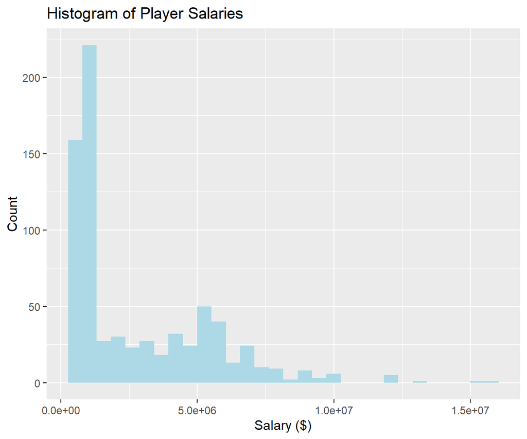

```r
ggplot(data_clean) +
  geom_histogram(aes(x = Salary), fill = "lightblue") +
  labs(title = "Histogram of Player Salaries",
       x = "Salary ($)",
       y = "Count")
```

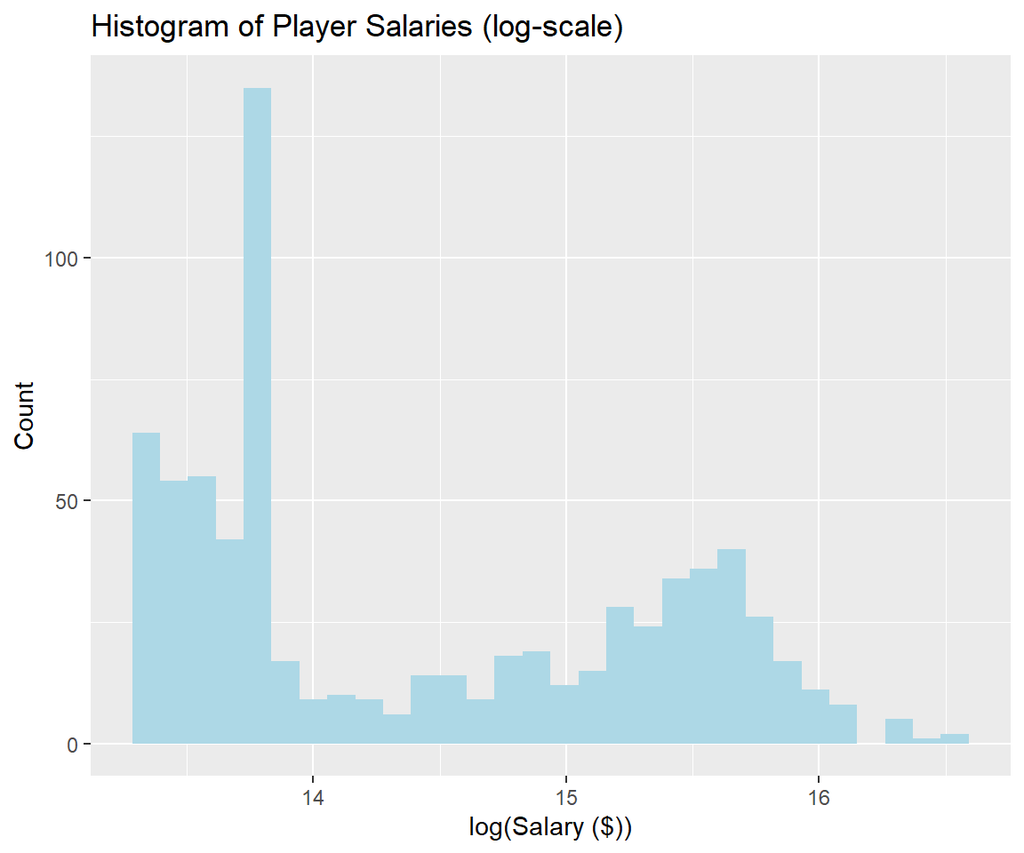

```r
ggplot(data_clean) +
  geom_histogram(aes(x = log(Salary)), fill = "lightblue") +
  labs(title = "Histogram of Player Salaries (log-scale)",
       x = "log(Salary ($))",
       y = "Count")
```

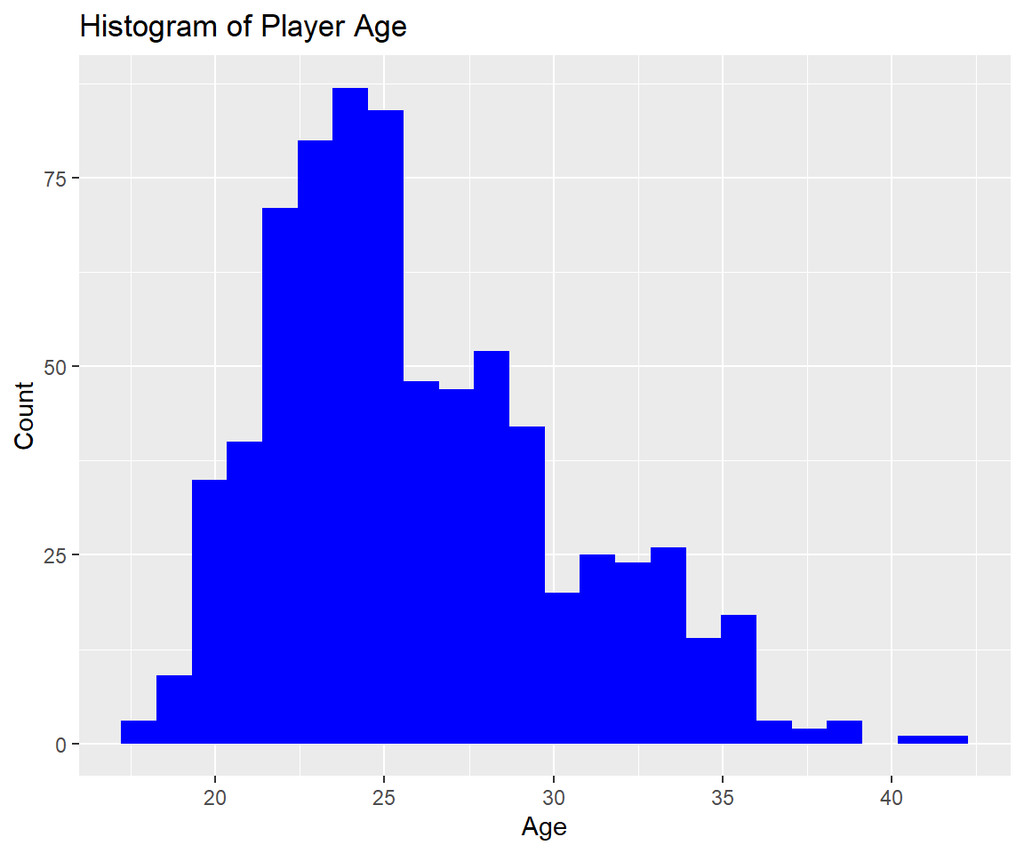

```r
ggplot(data_clean) +
  geom_histogram(aes(x = Age), fill = "blue", bins = 24) +
  labs(title = "Histogram of Player Age",
       x = "Age",
       y = "Count")
```

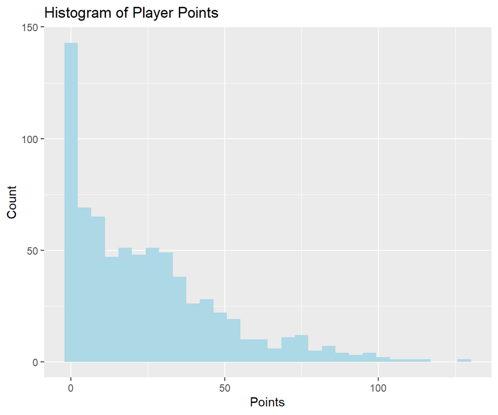

```r
ggplot(data_clean) +
  geom_histogram(aes(x = PTS), fill = "lightblue") +
  labs(title = "Histogram of Player Points",
       x = "Points",
       y = "Count")
```

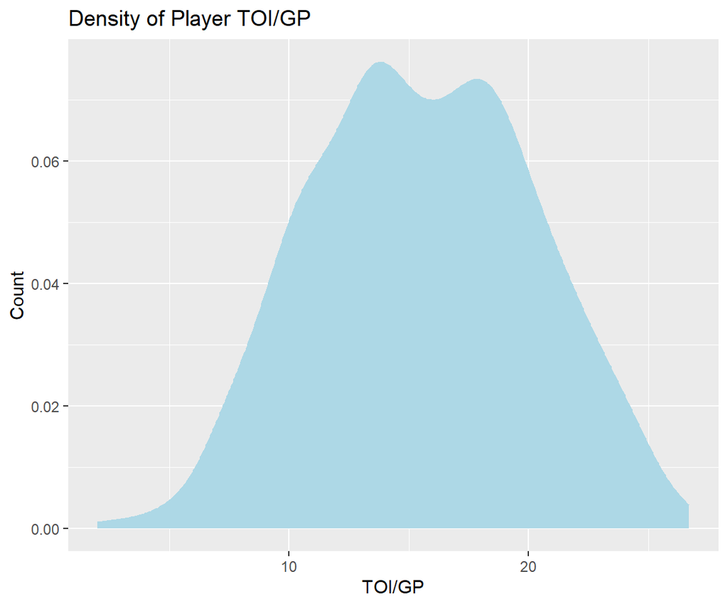

```r
ggplot(data_clean) +
  geom_density(aes(x = TOI), fill = "lightblue", color = "lightblue") +
  labs(title = "Density of Player TOI/GP",
       x = "TOI/GP",
       y = "Count")
```

## The first model: Linear Regression

The first model we’ll try here is Ordinary Least Squares. We’ll start by regressing salary on just age and points:

```r
mod1 = lm(Salary ~ Age + PTS, data = data_clean)
summary(mod1)
```

```
##
## Call:
## lm(formula = Salary ~ Age + PTS, data = data_clean)
##
## Residuals:
##      Min       1Q   Median       3Q      Max
## -5687180  -975176  -107395   769493  9973318
##
## Coefficients:
##             Estimate Std. Error t value Pr(>|t|)
## (Intercept) -5006819     408148  -12.27   <2e-16 ***
## Age           238643      15645   15.25   <2e-16 ***
## PTS            66051       2778   23.77   <2e-16 ***
## ---
## Signif. codes:  0 '***' 0.001 '**' 0.01 '*' 0.05 '.' 0.1 ' ' 1
##
## Residual standard error: 1764000 on 731 degrees of freedom
## Multiple R-squared:  0.5506, Adjusted R-squared:  0.5493
## F-statistic: 447.7 on 2 and 731 DF,  p-value: < 2.2e-16
```

We can do a whole lot better, though. Let’s try the same model, but with games played, age, points, shots, hits, and blocks:

```r
mod2 = lm(Salary ~ GP + Age + PTS + S + HIT + BLK, data = data_clean)
summary(mod2)
```

```
##
## Call:
## lm(formula = Salary ~ GP + Age + PTS + S + HIT + BLK, data = data_clean)
##
## Residuals:
##      Min       1Q   Median       3Q      Max
## -5370552  -888066   -39276   729823  9888489
##
## Coefficients:
##               Estimate Std. Error t value Pr(>|t|)
## (Intercept) -5251342.1   419286.2 -12.524  < 2e-16 ***
## GP            -18461.1     4580.1  -4.031 6.15e-05 ***
## Age           234584.4    15308.0  15.324  < 2e-16 ***
## PTS            61382.4     5436.0  11.292  < 2e-16 ***
## S             568109.4   123200.5   4.611 4.73e-06 ***
## HIT             -806.5     1463.6  -0.551    0.582
## BLK            13343.0     1943.2   6.866 1.41e-11 ***
## ---
## Signif. codes:  0 '***' 0.001 '**' 0.01 '*' 0.05 '.' 0.1 ' ' 1
##
## Residual standard error: 1687000 on 727 degrees of freedom
## Multiple R-squared:  0.5914, Adjusted R-squared:  0.588
## F-statistic: 175.4 on 6 and 727 DF,  p-value: < 2.2e-16
```

For the sake of completeness, what does the model look like with almost all of our columns added:

```r
mod3 = lm(Salary ~ . - PTS - D - PM, data = data_clean)
summary(mod3)
```

```
##
## Call:
## lm(formula = Salary ~ . - PTS - D - PM, data = data_clean)
##
## Residuals:
##      Min       1Q   Median       3Q      Max
## -4987814  -919987   -67355   800063  9223085
##
## Coefficients:
##             Estimate Std. Error t value Pr(>|t|)
## (Intercept) -6580313     583364 -11.280  < 2e-16 ***
## Age           222041      15248  14.562  < 2e-16 ***
## GP            -18237       4870  -3.745 0.000195 ***
## G              57100      19451   2.936 0.003436 **
## A              82002      12228   6.706 4.07e-11 ***
## PIM             5904       4049   1.458 0.145230
## PS           -171744      81891  -2.097 0.036326 *
## GWG           -85482      60127  -1.422 0.155554
## S             417243     142460   2.929 0.003511 **
## TOI           152223      33624   4.527 7.00e-06 ***
## BLK             4321       3431   1.260 0.208244
## HIT            -1130       1649  -0.685 0.493433
## FOW             4840       1703   2.842 0.004604 **
## FOL            -4142       1910  -2.169 0.030395 *
## HandedRight   124540     134401   0.927 0.354431
## C             -95109     276477  -0.344 0.730945
## LW            171166     291381   0.587 0.557100
## RW           -335015     298093  -1.124 0.261450
## canada       -139943     145101  -0.964 0.335143
## west          211454     121117   1.746 0.081264 .
## ---
## Signif. codes:  0 '***' 0.001 '**' 0.01 '*' 0.05 '.' 0.1 ' ' 1
##
## Residual standard error: 1611000 on 714 degrees of freedom
## Multiple R-squared:  0.6342, Adjusted R-squared:  0.6245
## F-statistic: 65.15 on 19 and 714 DF,  p-value: < 2.2e-16
```

## A non-linear model: Trees

Decision trees are a non-linear modeling technique where we make splits on the data in order to (in this case), fit smaller regression models on “more pure” subsets of the data defined by those splits. They’re more commonly used in classification exercises, so we’ll do both here, first fitting a model on the dataset to predict salary:

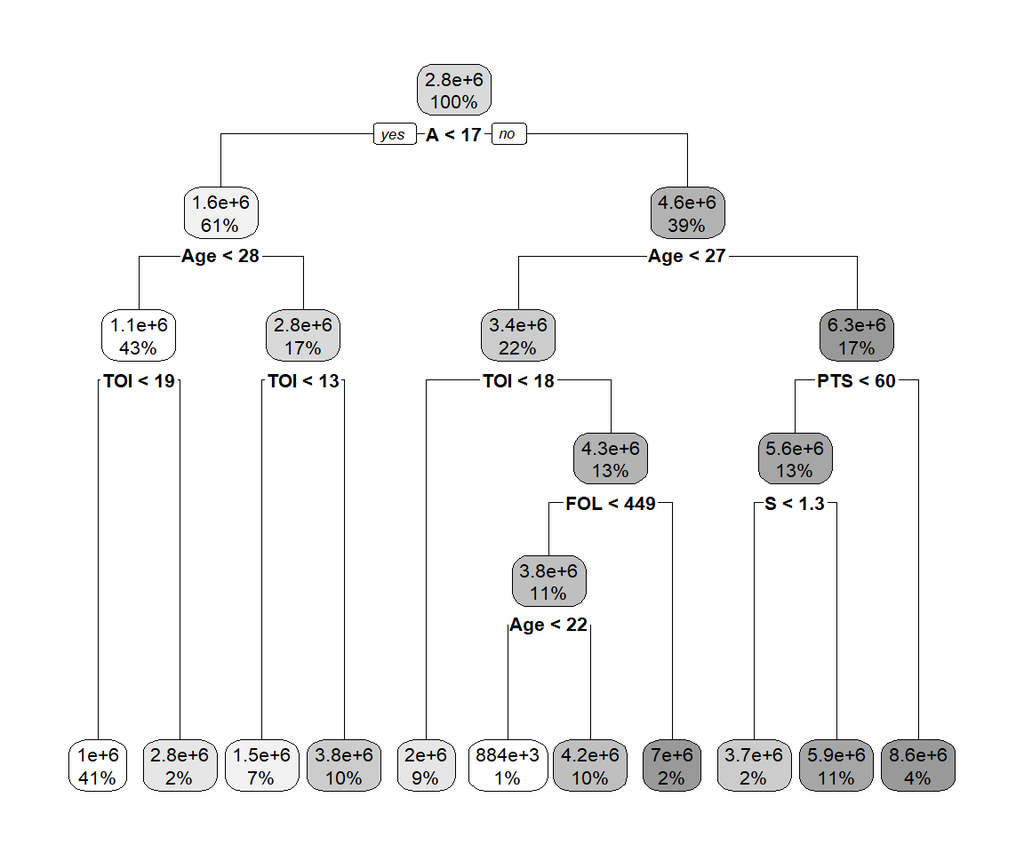

```r
tree1 = rpart(Salary ~ . - PM, data = data_clean,
              method = "anova")

rpart.plot(tree1, box.palette = "Grays", type = 2)
```

Okay, this tree is okay, but not spectacular. It might be nice to narrow this tree down to only splitting on a couple of variables we think would be useful:

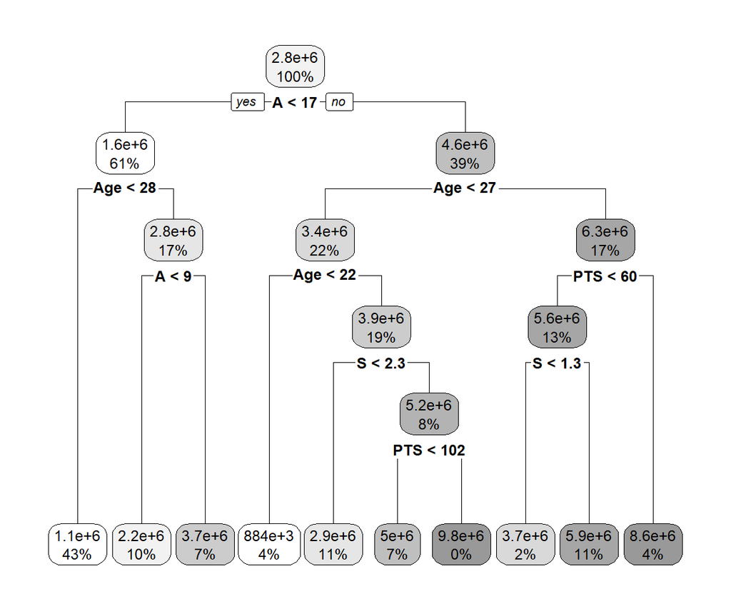

```r
tree2 = rpart(Salary ~ Age + GP + G + A + PTS + S, data = data_clean,
              method = "anova", minsplit = 10)

rpart.plot(tree2, box.palette = "Grays", type = 2)
```

This also isn’t great, 43% of our data is out in the far leaf on the left, and that’s not ideal. In a more rigorous setting, we would turn around and ask ourselves whether our data set was good, whether we’re even asking the right question here, and we would explore other modeling techniques for regression (such as a Bayesian model, if we have prior information to include).

### Trees for Classification

While on trees, we’ll end with a brief discussion of classification models. Classification is fairly intuitive, we’re attempting to use our data to predict the “class assignment” of an observation. Unlike regression, the response variable (what we’re predicting) is discrete, often a binary “yes/no”. As an example, we’ll use a tree, along with some of the variables we have, to try to predict if a player plays for a Western Conference team (the `west` variable is 1):

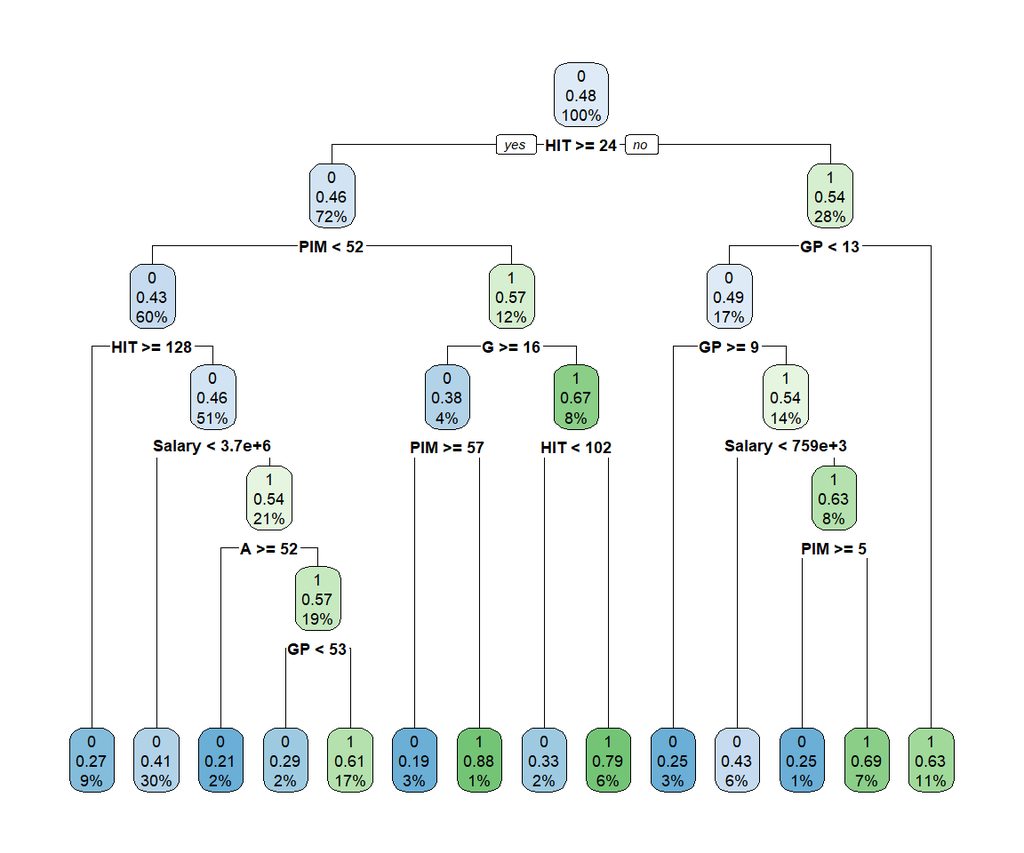

```r
tree3 = rpart(west ~ Age + GP + G + A + PTS + PIM + Salary + HIT + Handed,
              data = data_clean, method = "class", minsplit = 20)

rpart.plot(tree3, type = 2)
```

A couple of interesting things show up here, most noticeably that Hits and PIM are commonly used for split criteria. This example is, as with most of the others, fairly contrived. With more data, in a time series, you could choose to explore this in the context of how does play differ between the conferences and what does that tell us. To this point however, the purpose of this workshop is to introduce you to the very basics of modeling with sports data.

### Acknowledgements

Thank you to Hockey-Reference and CapFriendly for the data, and to Nick Kauffman for helping clean it up.